# Wrangle and Analyze Data Project

In this project we weill gather, wrangle and analyze Twitter data on dogs.

## Gather

Here we will gather 3 different data sets.

- The first is a file manually downloaded in the Udacity project details. It contails WeRateDogs Twitter archive.
- The second data set will be downleaded programmatically using the 'Requests' library. It contains tweet image predictions.
- The third data set will query the Twitter API for each tweet's JSON data(tweet ID's from WeRateDogs Twitter archive) using python's Tweepy library and store in a file called 'tweet_json.txt'. It will contain tweet ID, retweet count and favorite count.

```python
import pandas as pd

# The first file is a .csv file that was manually downloaded through a link
# Here we will open the file and save it in a dataframe

twitter_archive_enhanced = pd.read_csv('twitter-archive-enhanced.csv')
```

```python
# Check dataframe
twitter_archive_enhanced.head()
```

|  | tweet_id | in_reply_to_status_id | in_reply_to_user_id | timestamp | source | text | retweeted_status_id | retweeted_status_user_id | retweeted_status_timestamp | expanded_urls | rating_numerator | rating_denominator | name | doggo | floofer | pupper | puppo |
| --- | --- | --- | --- | --- | --- | --- | --- | --- | --- | --- | --- | --- | --- | --- | --- | --- | --- |
| 0 | 892420643555336193 | NaN | NaN | 2017-08-01 16:23:56 +0000 | <a href="http://twitter.com/download/iphone" r... | This is Phineas. He's a mystical boy. Only eve... | NaN | NaN | NaN | https://twitter.com/dog_rates/status/892420643... | 13 | 10 | Phineas | None | None | None | None |
| 1 | 892177421306343426 | NaN | NaN | 2017-08-01 00:17:27 +0000 | <a href="http://twitter.com/download/iphone" r... | This is Tilly. She's just checking pup on you.... | NaN | NaN | NaN | https://twitter.com/dog_rates/status/892177421... | 13 | 10 | Tilly | None | None | None | None |
| 2 | 891815181378084864 | NaN | NaN | 2017-07-31 00:18:03 +0000 | <a href="http://twitter.com/download/iphone" r... | This is Archie. He is a rare Norwegian Pouncin... | NaN | NaN | NaN | https://twitter.com/dog_rates/status/891815181... | 12 | 10 | Archie | None | None | None | None |
| 3 | 891689557279858688 | NaN | NaN | 2017-07-30 15:58:51 +0000 | <a href="http://twitter.com/download/iphone" r... | This is Darla. She commenced a snooze mid meal... | NaN | NaN | NaN | https://twitter.com/dog_rates/status/891689557... | 13 | 10 | Darla | None | None | None | None |
| 4 | 891327558926688256 | NaN | NaN | 2017-07-29 16:00:24 +0000 | <a href="http://twitter.com/download/iphone" r... | This is Franklin. He would like you to stop ca... | NaN | NaN | NaN | https://twitter.com/dog_rates/status/891327558... | 12 | 10 | Franklin | None | None | None | None |

```python
# The second data set will be downloaded programmatically using the Requests Library

image_predictions = pd.read_csv('https://d17h27t6h515a5.cloudfront.net/topher/2017/August/599fd2ad_image-predictions/image-predictions.tsv',sep='\t')

# Save file

image_predictions.to_csv('image_prediction.tsv', sep = '\t')
```

```python
#Check data frame
image_predictions.head()
```

|  | tweet_id | jpg_url | img_num | p1 | p1_conf | p1_dog | p2 | p2_conf | p2_dog | p3 | p3_conf | p3_dog |
| --- | --- | --- | --- | --- | --- | --- | --- | --- | --- | --- | --- | --- |
| 0 | 666020888022790149 | https://pbs.twimg.com/media/CT4udn0WwAA0aMy.jpg | 1 | Welsh_springer_spaniel | 0.465074 | True | collie | 0.156665 | True | Shetland_sheepdog | 0.061428 | True |
| 1 | 666029285002620928 | https://pbs.twimg.com/media/CT42GRgUYAA5iDo.jpg | 1 | redbone | 0.506826 | True | miniature_pinscher | 0.074192 | True | Rhodesian_ridgeback | 0.072010 | True |
| 2 | 666033412701032449 | https://pbs.twimg.com/media/CT4521TWwAEvMyu.jpg | 1 | German_shepherd | 0.596461 | True | malinois | 0.138584 | True | bloodhound | 0.116197 | True |
| 3 | 666044226329800704 | https://pbs.twimg.com/media/CT5Dr8HUEAA-lEu.jpg | 1 | Rhodesian_ridgeback | 0.408143 | True | redbone | 0.360687 | True | miniature_pinscher | 0.222752 | True |
| 4 | 666049248165822465 | https://pbs.twimg.com/media/CT5IQmsXIAAKY4A.jpg | 1 | miniature_pinscher | 0.560311 | True | Rottweiler | 0.243682 | True | Doberman | 0.154629 | True |

```python
# Check for duplicate tweet ID's from 'twitter_archive_enhanced'
print('Total tweet ID\'s:',len(twitter_archive_enhanced['tweet_id']))
print('Number of unique tweet ID\'s:',len(twitter_archive_enhanced['tweet_id'].unique()))
```

```
Total tweet ID's: 2356
Number of unique tweet ID's: 2356
```

```python
#  Reff https://s3.amazonaws.com/video.udacity-data.com/topher/2018/November/5be5fb4c_twitter-api/twitter-api.py
#  modified this code from udacity supporting materials

import tweepy
from tweepy import OAuthHandler
import json
from timeit import default_timer as timer

# Query Twitter API for each tweet in the Twitter archive and save JSON in a text file
# These are hidden to comply with Twitter's API terms and conditions
consumer_key = ''
consumer_secret = ''
access_token = '-'
access_secret = ''

auth = OAuthHandler(consumer_key, consumer_secret)
auth.set_access_token(access_token, access_secret)

api = tweepy.API(auth, wait_on_rate_limit=True)

# make list of tweet_id's
tweet_ids = twitter_archive_enhanced.tweet_id.values

# Query Twitter's API for JSON data for each tweet ID in the Twitter archive
count = 0
fails_dict = {}
start = timer()
# Save each tweet's returned JSON as a new line in a .txt file
with open('tweet_json.txt', 'w') as outfile:
    # This loop will likely take 20-30 minutes to run because of Twitter's rate limit
    for tweet_id in tweet_ids:
        count += 1
        print(str(count) + ": " + str(tweet_id))
        try:
            tweet = api.get_status(tweet_id, tweet_mode='extended')
            print("Success")
            json.dump(tweet._json, outfile)
            outfile.write('\n')
        except tweepy.TweepError as e:
            print("Fail")
            fails_dict[tweet_id] = e
            pass
end = timer()
print(end - start)
print(fails_dict)
```

[output not shown]

[output cut: 4659 more lines]

[output not shown]

```python
#  REF https://stackoverflow.com/questions/21058935/python-json-loads-shows-valueerror-extra-data
# Load data frame from saved data
import json

json_data = []  # need to make blank list to appended data line by line
for line in open('tweet_json.txt', 'r'):
    json_data.append(json.loads(line))

# now that we have the data we make a blank dataframe
tweet_json_data = pd.DataFrame()

# now make the dataframe from the dictionary text
tweet_json_data = tweet_json_data.from_dict(json_data)

# Parse data that is needed
tweet_json_data = tweet_json_data[['id','retweet_count','favorite_count','possibly_sensitive',
                                  'possibly_sensitive_appealable','created_at','display_text_range']]
#Change column 'id' to 'tweet_id'
tweet_json_data=tweet_json_data.rename(columns = {'id':'tweet_id'})
```

```python
# here we want to see how much data we were able to pull
print('Total number of twitter messages retrieved: ',len(tweet_json_data['tweet_id']))

# Here we want to see how many we were unable to pull
print('Number of of tweets we were NOT able to pull json code for: ', len(twitter_archive_enhanced['tweet_id'])-len(tweet_json_data['tweet_id']))
```

```
Total number of twitter messages retrieved:  2342
Number of of tweets we were NOT able to pull json code for:  14
```

# Assessing Data

Now that we have our data we will assess it for quality and tidyness issues for cleaning.

The three data sets we have are as follows:

- twitter_archive_enhanced; file manually downloaded. Contains basic tweet info.
- image_predictions; file downloaded programmatically downloaded. Contains image prediction data
- tweet_json_data; file programatically pulled code from twitter texts using twitter id's and tweepy. Contains json data. There were 14 tweet id's that we were unable to pull the json data for.

### Assesing: twitter_archive_enhanced

```python
# Visual assesment
twitter_archive_enhanced
```

|  | tweet_id | in_reply_to_status_id | in_reply_to_user_id | timestamp | source | text | retweeted_status_id | retweeted_status_user_id | retweeted_status_timestamp | expanded_urls | rating_numerator | rating_denominator | name | doggo | floofer | pupper | puppo |
| --- | --- | --- | --- | --- | --- | --- | --- | --- | --- | --- | --- | --- | --- | --- | --- | --- | --- |
| 0 | 892420643555336193 | NaN | NaN | 2017-08-01 16:23:56 +0000 | <a href="http://twitter.com/download/iphone" r... | This is Phineas. He's a mystical boy. Only eve... | NaN | NaN | NaN | https://twitter.com/dog_rates/status/892420643... | 13 | 10 | Phineas | None | None | None | None |
| 1 | 892177421306343426 | NaN | NaN | 2017-08-01 00:17:27 +0000 | <a href="http://twitter.com/download/iphone" r... | This is Tilly. She's just checking pup on you.... | NaN | NaN | NaN | https://twitter.com/dog_rates/status/892177421... | 13 | 10 | Tilly | None | None | None | None |
| 2 | 891815181378084864 | NaN | NaN | 2017-07-31 00:18:03 +0000 | <a href="http://twitter.com/download/iphone" r... | This is Archie. He is a rare Norwegian Pouncin... | NaN | NaN | NaN | https://twitter.com/dog_rates/status/891815181... | 12 | 10 | Archie | None | None | None | None |
| 3 | 891689557279858688 | NaN | NaN | 2017-07-30 15:58:51 +0000 | <a href="http://twitter.com/download/iphone" r... | This is Darla. She commenced a snooze mid meal... | NaN | NaN | NaN | https://twitter.com/dog_rates/status/891689557... | 13 | 10 | Darla | None | None | None | None |
| 4 | 891327558926688256 | NaN | NaN | 2017-07-29 16:00:24 +0000 | <a href="http://twitter.com/download/iphone" r... | This is Franklin. He would like you to stop ca... | NaN | NaN | NaN | https://twitter.com/dog_rates/status/891327558... | 12 | 10 | Franklin | None | None | None | None |
| 5 | 891087950875897856 | NaN | NaN | 2017-07-29 00:08:17 +0000 | <a href="http://twitter.com/download/iphone" r... | Here we have a majestic great white breaching ... | NaN | NaN | NaN | https://twitter.com/dog_rates/status/891087950... | 13 | 10 | None | None | None | None | None |
| 6 | 890971913173991426 | NaN | NaN | 2017-07-28 16:27:12 +0000 | <a href="http://twitter.com/download/iphone" r... | Meet Jax. He enjoys ice cream so much he gets ... | NaN | NaN | NaN | https://gofundme.com/ydvmve-surgery-for-jax,ht... | 13 | 10 | Jax | None | None | None | None |
| 7 | 890729181411237888 | NaN | NaN | 2017-07-28 00:22:40 +0000 | <a href="http://twitter.com/download/iphone" r... | When you watch your owner call another dog a g... | NaN | NaN | NaN | https://twitter.com/dog_rates/status/890729181... | 13 | 10 | None | None | None | None | None |
| 8 | 890609185150312448 | NaN | NaN | 2017-07-27 16:25:51 +0000 | <a href="http://twitter.com/download/iphone" r... | This is Zoey. She doesn't want to be one of th... | NaN | NaN | NaN | https://twitter.com/dog_rates/status/890609185... | 13 | 10 | Zoey | None | None | None | None |
| 9 | 890240255349198849 | NaN | NaN | 2017-07-26 15:59:51 +0000 | <a href="http://twitter.com/download/iphone" r... | This is Cassie. She is a college pup. Studying... | NaN | NaN | NaN | https://twitter.com/dog_rates/status/890240255... | 14 | 10 | Cassie | doggo | None | None | None |
| 10 | 890006608113172480 | NaN | NaN | 2017-07-26 00:31:25 +0000 | <a href="http://twitter.com/download/iphone" r... | This is Koda. He is a South Australian decksha... | NaN | NaN | NaN | https://twitter.com/dog_rates/status/890006608... | 13 | 10 | Koda | None | None | None | None |
| 11 | 889880896479866881 | NaN | NaN | 2017-07-25 16:11:53 +0000 | <a href="http://twitter.com/download/iphone" r... | This is Bruno. He is a service shark. Only get... | NaN | NaN | NaN | https://twitter.com/dog_rates/status/889880896... | 13 | 10 | Bruno | None | None | None | None |
| 12 | 889665388333682689 | NaN | NaN | 2017-07-25 01:55:32 +0000 | <a href="http://twitter.com/download/iphone" r... | Here's a puppo that seems to be on the fence a... | NaN | NaN | NaN | https://twitter.com/dog_rates/status/889665388... | 13 | 10 | None | None | None | None | puppo |
| 13 | 889638837579907072 | NaN | NaN | 2017-07-25 00:10:02 +0000 | <a href="http://twitter.com/download/iphone" r... | This is Ted. He does his best. Sometimes that'... | NaN | NaN | NaN | https://twitter.com/dog_rates/status/889638837... | 12 | 10 | Ted | None | None | None | None |
| 14 | 889531135344209921 | NaN | NaN | 2017-07-24 17:02:04 +0000 | <a href="http://twitter.com/download/iphone" r... | This is Stuart. He's sporting his favorite fan... | NaN | NaN | NaN | https://twitter.com/dog_rates/status/889531135... | 13 | 10 | Stuart | None | None | None | puppo |
| 15 | 889278841981685760 | NaN | NaN | 2017-07-24 00:19:32 +0000 | <a href="http://twitter.com/download/iphone" r... | This is Oliver. You're witnessing one of his m... | NaN | NaN | NaN | https://twitter.com/dog_rates/status/889278841... | 13 | 10 | Oliver | None | None | None | None |
| 16 | 888917238123831296 | NaN | NaN | 2017-07-23 00:22:39 +0000 | <a href="http://twitter.com/download/iphone" r... | This is Jim. He found a fren. Taught him how t... | NaN | NaN | NaN | https://twitter.com/dog_rates/status/888917238... | 12 | 10 | Jim | None | None | None | None |
| 17 | 888804989199671297 | NaN | NaN | 2017-07-22 16:56:37 +0000 | <a href="http://twitter.com/download/iphone" r... | This is Zeke. He has a new stick. Very proud o... | NaN | NaN | NaN | https://twitter.com/dog_rates/status/888804989... | 13 | 10 | Zeke | None | None | None | None |
| 18 | 888554962724278272 | NaN | NaN | 2017-07-22 00:23:06 +0000 | <a href="http://twitter.com/download/iphone" r... | This is Ralphus. He's powering up. Attempting ... | NaN | NaN | NaN | https://twitter.com/dog_rates/status/888554962... | 13 | 10 | Ralphus | None | None | None | None |
| 19 | 888202515573088257 | NaN | NaN | 2017-07-21 01:02:36 +0000 | <a href="http://twitter.com/download/iphone" r... | RT @dog_rates: This is Canela. She attempted s... | 8.874740e+17 | 4.196984e+09 | 2017-07-19 00:47:34 +0000 | https://twitter.com/dog_rates/status/887473957... | 13 | 10 | Canela | None | None | None | None |
| 20 | 888078434458587136 | NaN | NaN | 2017-07-20 16:49:33 +0000 | <a href="http://twitter.com/download/iphone" r... | This is Gerald. He was just told he didn't get... | NaN | NaN | NaN | https://twitter.com/dog_rates/status/888078434... | 12 | 10 | Gerald | None | None | None | None |
| 21 | 887705289381826560 | NaN | NaN | 2017-07-19 16:06:48 +0000 | <a href="http://twitter.com/download/iphone" r... | This is Jeffrey. He has a monopoly on the pool... | NaN | NaN | NaN | https://twitter.com/dog_rates/status/887705289... | 13 | 10 | Jeffrey | None | None | None | None |
| 22 | 887517139158093824 | NaN | NaN | 2017-07-19 03:39:09 +0000 | <a href="http://twitter.com/download/iphone" r... | I've yet to rate a Venezuelan Hover Wiener. Th... | NaN | NaN | NaN | https://twitter.com/dog_rates/status/887517139... | 14 | 10 | such | None | None | None | None |
| 23 | 887473957103951883 | NaN | NaN | 2017-07-19 00:47:34 +0000 | <a href="http://twitter.com/download/iphone" r... | This is Canela. She attempted some fancy porch... | NaN | NaN | NaN | https://twitter.com/dog_rates/status/887473957... | 13 | 10 | Canela | None | None | None | None |
| 24 | 887343217045368832 | NaN | NaN | 2017-07-18 16:08:03 +0000 | <a href="http://twitter.com/download/iphone" r... | You may not have known you needed to see this ... | NaN | NaN | NaN | https://twitter.com/dog_rates/status/887343217... | 13 | 10 | None | None | None | None | None |
| 25 | 887101392804085760 | NaN | NaN | 2017-07-18 00:07:08 +0000 | <a href="http://twitter.com/download/iphone" r... | This... is a Jubilant Antarctic House Bear. We... | NaN | NaN | NaN | https://twitter.com/dog_rates/status/887101392... | 12 | 10 | None | None | None | None | None |
| 26 | 886983233522544640 | NaN | NaN | 2017-07-17 16:17:36 +0000 | <a href="http://twitter.com/download/iphone" r... | This is Maya. She's very shy. Rarely leaves he... | NaN | NaN | NaN | https://twitter.com/dog_rates/status/886983233... | 13 | 10 | Maya | None | None | None | None |
| 27 | 886736880519319552 | NaN | NaN | 2017-07-16 23:58:41 +0000 | <a href="http://twitter.com/download/iphone" r... | This is Mingus. He's a wonderful father to his... | NaN | NaN | NaN | https://www.gofundme.com/mingusneedsus,https:/... | 13 | 10 | Mingus | None | None | None | None |
| 28 | 886680336477933568 | NaN | NaN | 2017-07-16 20:14:00 +0000 | <a href="http://twitter.com/download/iphone" r... | This is Derek. He's late for a dog meeting. 13... | NaN | NaN | NaN | https://twitter.com/dog_rates/status/886680336... | 13 | 10 | Derek | None | None | None | None |
| 29 | 886366144734445568 | NaN | NaN | 2017-07-15 23:25:31 +0000 | <a href="http://twitter.com/download/iphone" r... | This is Roscoe. Another pupper fallen victim t... | NaN | NaN | NaN | https://twitter.com/dog_rates/status/886366144... | 12 | 10 | Roscoe | None | None | pupper | None |
| ... | ... | ... | ... | ... | ... | ... | ... | ... | ... | ... | ... | ... | ... | ... | ... | ... | ... |
| 2326 | 666411507551481857 | NaN | NaN | 2015-11-17 00:24:19 +0000 | <a href="http://twitter.com/download/iphone" r... | This is quite the dog. Gets really excited whe... | NaN | NaN | NaN | https://twitter.com/dog_rates/status/666411507... | 2 | 10 | quite | None | None | None | None |
| 2327 | 666407126856765440 | NaN | NaN | 2015-11-17 00:06:54 +0000 | <a href="http://twitter.com/download/iphone" r... | This is a southern Vesuvius bumblegruff. Can d... | NaN | NaN | NaN | https://twitter.com/dog_rates/status/666407126... | 7 | 10 | a | None | None | None | None |
| 2328 | 666396247373291520 | NaN | NaN | 2015-11-16 23:23:41 +0000 | <a href="http://twitter.com/download/iphone" r... | Oh goodness. A super rare northeast Qdoba kang... | NaN | NaN | NaN | https://twitter.com/dog_rates/status/666396247... | 9 | 10 | None | None | None | None | None |
| 2329 | 666373753744588802 | NaN | NaN | 2015-11-16 21:54:18 +0000 | <a href="http://twitter.com/download/iphone" r... | Those are sunglasses and a jean jacket. 11/10 ... | NaN | NaN | NaN | https://twitter.com/dog_rates/status/666373753... | 11 | 10 | None | None | None | None | None |
| 2330 | 666362758909284353 | NaN | NaN | 2015-11-16 21:10:36 +0000 | <a href="http://twitter.com/download/iphone" r... | Unique dog here. Very small. Lives in containe... | NaN | NaN | NaN | https://twitter.com/dog_rates/status/666362758... | 6 | 10 | None | None | None | None | None |
| 2331 | 666353288456101888 | NaN | NaN | 2015-11-16 20:32:58 +0000 | <a href="http://twitter.com/download/iphone" r... | Here we have a mixed Asiago from the Galápagos... | NaN | NaN | NaN | https://twitter.com/dog_rates/status/666353288... | 8 | 10 | None | None | None | None | None |
| 2332 | 666345417576210432 | NaN | NaN | 2015-11-16 20:01:42 +0000 | <a href="http://twitter.com/download/iphone" r... | Look at this jokester thinking seat belt laws ... | NaN | NaN | NaN | https://twitter.com/dog_rates/status/666345417... | 10 | 10 | None | None | None | None | None |
| 2333 | 666337882303524864 | NaN | NaN | 2015-11-16 19:31:45 +0000 | <a href="http://twitter.com/download/iphone" r... | This is an extremely rare horned Parthenon. No... | NaN | NaN | NaN | https://twitter.com/dog_rates/status/666337882... | 9 | 10 | an | None | None | None | None |
| 2334 | 666293911632134144 | NaN | NaN | 2015-11-16 16:37:02 +0000 | <a href="http://twitter.com/download/iphone" r... | This is a funny dog. Weird toes. Won't come do... | NaN | NaN | NaN | https://twitter.com/dog_rates/status/666293911... | 3 | 10 | a | None | None | None | None |
| 2335 | 666287406224695296 | NaN | NaN | 2015-11-16 16:11:11 +0000 | <a href="http://twitter.com/download/iphone" r... | This is an Albanian 3 1/2 legged Episcopalian... | NaN | NaN | NaN | https://twitter.com/dog_rates/status/666287406... | 1 | 2 | an | None | None | None | None |
| 2336 | 666273097616637952 | NaN | NaN | 2015-11-16 15:14:19 +0000 | <a href="http://twitter.com/download/iphone" r... | Can take selfies 11/10 https://t.co/ws2AMaNwPW | NaN | NaN | NaN | https://twitter.com/dog_rates/status/666273097... | 11 | 10 | None | None | None | None | None |
| 2337 | 666268910803644416 | NaN | NaN | 2015-11-16 14:57:41 +0000 | <a href="http://twitter.com/download/iphone" r... | Very concerned about fellow dog trapped in com... | NaN | NaN | NaN | https://twitter.com/dog_rates/status/666268910... | 10 | 10 | None | None | None | None | None |
| 2338 | 666104133288665088 | NaN | NaN | 2015-11-16 04:02:55 +0000 | <a href="http://twitter.com/download/iphone" r... | Not familiar with this breed. No tail (weird).... | NaN | NaN | NaN | https://twitter.com/dog_rates/status/666104133... | 1 | 10 | None | None | None | None | None |
| 2339 | 666102155909144576 | NaN | NaN | 2015-11-16 03:55:04 +0000 | <a href="http://twitter.com/download/iphone" r... | Oh my. Here you are seeing an Adobe Setter giv... | NaN | NaN | NaN | https://twitter.com/dog_rates/status/666102155... | 11 | 10 | None | None | None | None | None |
| 2340 | 666099513787052032 | NaN | NaN | 2015-11-16 03:44:34 +0000 | <a href="http://twitter.com/download/iphone" r... | Can stand on stump for what seems like a while... | NaN | NaN | NaN | https://twitter.com/dog_rates/status/666099513... | 8 | 10 | None | None | None | None | None |
| 2341 | 666094000022159362 | NaN | NaN | 2015-11-16 03:22:39 +0000 | <a href="http://twitter.com/download/iphone" r... | This appears to be a Mongolian Presbyterian mi... | NaN | NaN | NaN | https://twitter.com/dog_rates/status/666094000... | 9 | 10 | None | None | None | None | None |
| 2342 | 666082916733198337 | NaN | NaN | 2015-11-16 02:38:37 +0000 | <a href="http://twitter.com/download/iphone" r... | Here we have a well-established sunblockerspan... | NaN | NaN | NaN | https://twitter.com/dog_rates/status/666082916... | 6 | 10 | None | None | None | None | None |
| 2343 | 666073100786774016 | NaN | NaN | 2015-11-16 01:59:36 +0000 | <a href="http://twitter.com/download/iphone" r... | Let's hope this flight isn't Malaysian (lol). ... | NaN | NaN | NaN | https://twitter.com/dog_rates/status/666073100... | 10 | 10 | None | None | None | None | None |
| 2344 | 666071193221509120 | NaN | NaN | 2015-11-16 01:52:02 +0000 | <a href="http://twitter.com/download/iphone" r... | Here we have a northern speckled Rhododendron.... | NaN | NaN | NaN | https://twitter.com/dog_rates/status/666071193... | 9 | 10 | None | None | None | None | None |
| 2345 | 666063827256086533 | NaN | NaN | 2015-11-16 01:22:45 +0000 | <a href="http://twitter.com/download/iphone" r... | This is the happiest dog you will ever see. Ve... | NaN | NaN | NaN | https://twitter.com/dog_rates/status/666063827... | 10 | 10 | the | None | None | None | None |
| 2346 | 666058600524156928 | NaN | NaN | 2015-11-16 01:01:59 +0000 | <a href="http://twitter.com/download/iphone" r... | Here is the Rand Paul of retrievers folks! He'... | NaN | NaN | NaN | https://twitter.com/dog_rates/status/666058600... | 8 | 10 | the | None | None | None | None |
| 2347 | 666057090499244032 | NaN | NaN | 2015-11-16 00:55:59 +0000 | <a href="http://twitter.com/download/iphone" r... | My oh my. This is a rare blond Canadian terrie... | NaN | NaN | NaN | https://twitter.com/dog_rates/status/666057090... | 9 | 10 | a | None | None | None | None |
| 2348 | 666055525042405380 | NaN | NaN | 2015-11-16 00:49:46 +0000 | <a href="http://twitter.com/download/iphone" r... | Here is a Siberian heavily armored polar bear ... | NaN | NaN | NaN | https://twitter.com/dog_rates/status/666055525... | 10 | 10 | a | None | None | None | None |
| 2349 | 666051853826850816 | NaN | NaN | 2015-11-16 00:35:11 +0000 | <a href="http://twitter.com/download/iphone" r... | This is an odd dog. Hard on the outside but lo... | NaN | NaN | NaN | https://twitter.com/dog_rates/status/666051853... | 2 | 10 | an | None | None | None | None |
| 2350 | 666050758794694657 | NaN | NaN | 2015-11-16 00:30:50 +0000 | <a href="http://twitter.com/download/iphone" r... | This is a truly beautiful English Wilson Staff... | NaN | NaN | NaN | https://twitter.com/dog_rates/status/666050758... | 10 | 10 | a | None | None | None | None |
| 2351 | 666049248165822465 | NaN | NaN | 2015-11-16 00:24:50 +0000 | <a href="http://twitter.com/download/iphone" r... | Here we have a 1949 1st generation vulpix. Enj... | NaN | NaN | NaN | https://twitter.com/dog_rates/status/666049248... | 5 | 10 | None | None | None | None | None |
| 2352 | 666044226329800704 | NaN | NaN | 2015-11-16 00:04:52 +0000 | <a href="http://twitter.com/download/iphone" r... | This is a purebred Piers Morgan. Loves to Netf... | NaN | NaN | NaN | https://twitter.com/dog_rates/status/666044226... | 6 | 10 | a | None | None | None | None |
| 2353 | 666033412701032449 | NaN | NaN | 2015-11-15 23:21:54 +0000 | <a href="http://twitter.com/download/iphone" r... | Here is a very happy pup. Big fan of well-main... | NaN | NaN | NaN | https://twitter.com/dog_rates/status/666033412... | 9 | 10 | a | None | None | None | None |
| 2354 | 666029285002620928 | NaN | NaN | 2015-11-15 23:05:30 +0000 | <a href="http://twitter.com/download/iphone" r... | This is a western brown Mitsubishi terrier. Up... | NaN | NaN | NaN | https://twitter.com/dog_rates/status/666029285... | 7 | 10 | a | None | None | None | None |
| 2355 | 666020888022790149 | NaN | NaN | 2015-11-15 22:32:08 +0000 | <a href="http://twitter.com/download/iphone" r... | Here we have a Japanese Irish Setter. Lost eye... | NaN | NaN | NaN | https://twitter.com/dog_rates/status/666020888... | 8 | 10 | None | None | None | None | None |

2356 rows × 17 columns

```python
twitter_archive_enhanced.info()
```

```
<class 'pandas.core.frame.DataFrame'>
RangeIndex: 2356 entries, 0 to 2355
Data columns (total 17 columns):
tweet_id                      2356 non-null int64
in_reply_to_status_id         78 non-null float64
in_reply_to_user_id           78 non-null float64
timestamp                     2356 non-null object
source                        2356 non-null object
text                          2356 non-null object
retweeted_status_id           181 non-null float64
retweeted_status_user_id      181 non-null float64
retweeted_status_timestamp    181 non-null object
expanded_urls                 2297 non-null object
rating_numerator              2356 non-null int64
rating_denominator            2356 non-null int64
name                          2356 non-null object
doggo                         2356 non-null object
floofer                       2356 non-null object
pupper                        2356 non-null object
puppo                         2356 non-null object
dtypes: float64(4), int64(3), object(10)
memory usage: 313.0+ KB
```

#### Assessing Rating

Here we will assess the numerical values of the rating numerator and denominator to determine if there are any values that may be errors.

```python
twitter_archive_enhanced.describe()
```

|  | tweet_id | in_reply_to_status_id | in_reply_to_user_id | retweeted_status_id | retweeted_status_user_id | rating_numerator | rating_denominator |
| --- | --- | --- | --- | --- | --- | --- | --- |
| count | 2.356000e+03 | 7.800000e+01 | 7.800000e+01 | 1.810000e+02 | 1.810000e+02 | 2356.000000 | 2356.000000 |
| mean | 7.427716e+17 | 7.455079e+17 | 2.014171e+16 | 7.720400e+17 | 1.241698e+16 | 13.126486 | 10.455433 |
| std | 6.856705e+16 | 7.582492e+16 | 1.252797e+17 | 6.236928e+16 | 9.599254e+16 | 45.876648 | 6.745237 |
| min | 6.660209e+17 | 6.658147e+17 | 1.185634e+07 | 6.661041e+17 | 7.832140e+05 | 0.000000 | 0.000000 |
| 25% | 6.783989e+17 | 6.757419e+17 | 3.086374e+08 | 7.186315e+17 | 4.196984e+09 | 10.000000 | 10.000000 |
| 50% | 7.196279e+17 | 7.038708e+17 | 4.196984e+09 | 7.804657e+17 | 4.196984e+09 | 11.000000 | 10.000000 |
| 75% | 7.993373e+17 | 8.257804e+17 | 4.196984e+09 | 8.203146e+17 | 4.196984e+09 | 12.000000 | 10.000000 |
| max | 8.924206e+17 | 8.862664e+17 | 8.405479e+17 | 8.874740e+17 | 7.874618e+17 | 1776.000000 | 170.000000 |

###### Note

There appear to be some very large numbers for numerator and denominator. There also appears to be a zero. We will further investigate

```python
from collections import Counter
# Check numerator
Counter(twitter_archive_enhanced['rating_numerator'])
```

```
Counter({13: 351,
         12: 558,
         14: 54,
         5: 37,
         17: 1,
         11: 464,
         10: 461,
         420: 2,
         666: 1,
         6: 32,
         15: 2,
         182: 1,
         960: 1,
         0: 2,
         75: 2,
```

[output cut: 25 more lines]

```python
#Check denominator
Counter(twitter_archive_enhanced['rating_denominator'])
```

```
Counter({10: 2333,
         0: 1,
         15: 1,
         70: 1,
         7: 1,
         11: 3,
         150: 1,
         170: 1,
         20: 2,
         50: 3,
         90: 1,
         80: 2,
         40: 1,
         130: 1,
         110: 1,
         16: 1,
         120: 1,
         2: 1})
```

```python
# You cannot divide by zero so we want to inspect where 0 is in the denominator
twitter_archive_enhanced[['rating_numerator','rating_denominator']][twitter_archive_enhanced['rating_denominator'] != 10]
```

|  | rating_numerator | rating_denominator |
| --- | --- | --- |
| 313 | 960 | 0 |
| 342 | 11 | 15 |
| 433 | 84 | 70 |
| 516 | 24 | 7 |
| 784 | 9 | 11 |
| 902 | 165 | 150 |
| 1068 | 9 | 11 |
| 1120 | 204 | 170 |
| 1165 | 4 | 20 |
| 1202 | 50 | 50 |
| 1228 | 99 | 90 |
| 1254 | 80 | 80 |
| 1274 | 45 | 50 |
| 1351 | 60 | 50 |
| 1433 | 44 | 40 |
| 1598 | 4 | 20 |
| 1634 | 143 | 130 |
| 1635 | 121 | 110 |
| 1662 | 7 | 11 |
| 1663 | 20 | 16 |
| 1779 | 144 | 120 |
| 1843 | 88 | 80 |
| 2335 | 1 | 2 |

```python
# inspect where 0 is in the numerator
twitter_archive_enhanced[['rating_numerator','rating_denominator']][twitter_archive_enhanced['rating_numerator'] == 0]
```

|  | rating_numerator | rating_denominator |
| --- | --- | --- |
| 315 | 0 | 10 |
| 1016 | 0 | 10 |

```python
twitter_archive_enhanced[twitter_archive_enhanced['rating_numerator'] == 0]
#I wanted to see the posts myself and it appears it is correct rating 0/10
```

|  | tweet_id | in_reply_to_status_id | in_reply_to_user_id | timestamp | source | text | retweeted_status_id | retweeted_status_user_id | retweeted_status_timestamp | expanded_urls | rating_numerator | rating_denominator | name | doggo | floofer | pupper | puppo |
| --- | --- | --- | --- | --- | --- | --- | --- | --- | --- | --- | --- | --- | --- | --- | --- | --- | --- |
| 315 | 835152434251116546 | NaN | NaN | 2017-02-24 15:40:31 +0000 | <a href="http://twitter.com/download/iphone" r... | When you're so blinded by your systematic plag... | NaN | NaN | NaN | https://twitter.com/dog_rates/status/835152434... | 0 | 10 | None | None | None | None | None |
| 1016 | 746906459439529985 | 7.468859e+17 | 4.196984e+09 | 2016-06-26 03:22:31 +0000 | <a href="http://twitter.com/download/iphone" r... | PUPDATE: can't see any. Even if I could, I cou... | NaN | NaN | NaN | https://twitter.com/dog_rates/status/746906459... | 0 | 10 | None | None | None | None | None |

```python
# Check for any names that may have been incorrect
print(twitter_archive_enhanced['name'].value_counts())
```

```
None            745
a                55
Charlie          12
Oliver           11
Cooper           11
Lucy             11
Tucker           10
Lola             10
Penny            10
Winston           9
Bo                9
Sadie             8
the               8
Bailey            7
an                7
Toby              7
Daisy             7
Buddy             7
Koda              6
Milo              6
Oscar             6
Rusty             6
Leo               6
Dave              6
Bella             6
Stanley           6
Jax               6
Jack              6
Scout             6
Finn              5
               ...
Snicku            1
Cedrick           1
Banditt           1
Pupcasso          1
Huck              1
Tedders           1
Aqua              1
Jeffrie           1
Robin             1
Nigel             1
Mitch             1
Buckley           1
Grady             1
Bonaparte         1
Kial              1
Tom               1
Gustav            1
Mabel             1
Dallas            1
unacceptable      1
Grey              1
Brandonald        1
Rueben            1
Cleopatricia      1
Maisey            1
Alf               1
Schnitzel         1
Chadrick          1
Moofasa           1
Lulu              1
Name: name, Length: 957, dtype: int64
```

```python
# Check timestamp
twitter_archive_enhanced['timestamp'].head()
```

```
0    2017-08-01 16:23:56 +0000
1    2017-08-01 00:17:27 +0000
2    2017-07-31 00:18:03 +0000
3    2017-07-30 15:58:51 +0000
4    2017-07-29 16:00:24 +0000
Name: timestamp, dtype: object
```

```python
list(twitter_archive_enhanced)
```

```
['tweet_id',
 'in_reply_to_status_id',
 'in_reply_to_user_id',
 'timestamp',
 'source',
 'text',
 'retweeted_status_id',
 'retweeted_status_user_id',
 'retweeted_status_timestamp',
 'expanded_urls',
 'rating_numerator',
 'rating_denominator',
 'name',
 'doggo',
 'floofer',
 'pupper',
 'puppo']
```

```python
twitter_archive_enhanced['in_reply_to_user_id'][pd.notna(twitter_archive_enhanced['in_reply_to_user_id'])].head()
```

```
30     2.281182e+09
55     4.738443e+07
64     3.105441e+09
113    1.648776e+07
148    7.759620e+07
Name: in_reply_to_user_id, dtype: float64
```

```python
twitter_archive_enhanced['in_reply_to_user_id'][30]
```

```
2281181600.0
```

```python
twitter_archive_enhanced['in_reply_to_status_id'][pd.notna(twitter_archive_enhanced['in_reply_to_status_id'])].head()
```

```
30     8.862664e+17
55     8.816070e+17
64     8.795538e+17
113    8.707262e+17
148    8.634256e+17
Name: in_reply_to_status_id, dtype: float64
```

```python
twitter_archive_enhanced_clean['in_reply_to_status_id'][30]
```

[output not shown]

#### Changes

- Rating denominator = 0; all other values appear reasonable.
- Name = (a, an, the); These are not dog names and should be changed to 'None'.
- Create a rating category to calculate 'rating_numerator'/'rating_denominator'.
- `time_stamp` change to elapsed days
- `in_reply_to_user_id` change to string to remove zero after decimal.
- `in_reply_to_status_id` change to string to remove zero after decimal.

### Assessing: image_predictions

```python
# visual inspection
image_predictions
```

|  | tweet_id | jpg_url | img_num | p1 | p1_conf | p1_dog | p2 | p2_conf | p2_dog | p3 | p3_conf | p3_dog |
| --- | --- | --- | --- | --- | --- | --- | --- | --- | --- | --- | --- | --- |
| 0 | 666020888022790149 | https://pbs.twimg.com/media/CT4udn0WwAA0aMy.jpg | 1 | Welsh_springer_spaniel | 0.465074 | True | collie | 0.156665 | True | Shetland_sheepdog | 0.061428 | True |
| 1 | 666029285002620928 | https://pbs.twimg.com/media/CT42GRgUYAA5iDo.jpg | 1 | redbone | 0.506826 | True | miniature_pinscher | 0.074192 | True | Rhodesian_ridgeback | 0.072010 | True |
| 2 | 666033412701032449 | https://pbs.twimg.com/media/CT4521TWwAEvMyu.jpg | 1 | German_shepherd | 0.596461 | True | malinois | 0.138584 | True | bloodhound | 0.116197 | True |
| 3 | 666044226329800704 | https://pbs.twimg.com/media/CT5Dr8HUEAA-lEu.jpg | 1 | Rhodesian_ridgeback | 0.408143 | True | redbone | 0.360687 | True | miniature_pinscher | 0.222752 | True |
| 4 | 666049248165822465 | https://pbs.twimg.com/media/CT5IQmsXIAAKY4A.jpg | 1 | miniature_pinscher | 0.560311 | True | Rottweiler | 0.243682 | True | Doberman | 0.154629 | True |
| 5 | 666050758794694657 | https://pbs.twimg.com/media/CT5Jof1WUAEuVxN.jpg | 1 | Bernese_mountain_dog | 0.651137 | True | English_springer | 0.263788 | True | Greater_Swiss_Mountain_dog | 0.016199 | True |
| 6 | 666051853826850816 | https://pbs.twimg.com/media/CT5KoJ1WoAAJash.jpg | 1 | box_turtle | 0.933012 | False | mud_turtle | 0.045885 | False | terrapin | 0.017885 | False |
| 7 | 666055525042405380 | https://pbs.twimg.com/media/CT5N9tpXIAAifs1.jpg | 1 | chow | 0.692517 | True | Tibetan_mastiff | 0.058279 | True | fur_coat | 0.054449 | False |
| 8 | 666057090499244032 | https://pbs.twimg.com/media/CT5PY90WoAAQGLo.jpg | 1 | shopping_cart | 0.962465 | False | shopping_basket | 0.014594 | False | golden_retriever | 0.007959 | True |
| 9 | 666058600524156928 | https://pbs.twimg.com/media/CT5Qw94XAAA_2dP.jpg | 1 | miniature_poodle | 0.201493 | True | komondor | 0.192305 | True | soft-coated_wheaten_terrier | 0.082086 | True |
| 10 | 666063827256086533 | https://pbs.twimg.com/media/CT5Vg_wXIAAXfnj.jpg | 1 | golden_retriever | 0.775930 | True | Tibetan_mastiff | 0.093718 | True | Labrador_retriever | 0.072427 | True |
| 11 | 666071193221509120 | https://pbs.twimg.com/media/CT5cN_3WEAAlOoZ.jpg | 1 | Gordon_setter | 0.503672 | True | Yorkshire_terrier | 0.174201 | True | Pekinese | 0.109454 | True |
| 12 | 666073100786774016 | https://pbs.twimg.com/media/CT5d9DZXAAALcwe.jpg | 1 | Walker_hound | 0.260857 | True | English_foxhound | 0.175382 | True | Ibizan_hound | 0.097471 | True |
| 13 | 666082916733198337 | https://pbs.twimg.com/media/CT5m4VGWEAAtKc8.jpg | 1 | pug | 0.489814 | True | bull_mastiff | 0.404722 | True | French_bulldog | 0.048960 | True |
| 14 | 666094000022159362 | https://pbs.twimg.com/media/CT5w9gUW4AAsBNN.jpg | 1 | bloodhound | 0.195217 | True | German_shepherd | 0.078260 | True | malinois | 0.075628 | True |
| 15 | 666099513787052032 | https://pbs.twimg.com/media/CT51-JJUEAA6hV8.jpg | 1 | Lhasa | 0.582330 | True | Shih-Tzu | 0.166192 | True | Dandie_Dinmont | 0.089688 | True |
| 16 | 666102155909144576 | https://pbs.twimg.com/media/CT54YGiWUAEZnoK.jpg | 1 | English_setter | 0.298617 | True | Newfoundland | 0.149842 | True | borzoi | 0.133649 | True |
| 17 | 666104133288665088 | https://pbs.twimg.com/media/CT56LSZWoAAlJj2.jpg | 1 | hen | 0.965932 | False | cock | 0.033919 | False | partridge | 0.000052 | False |
| 18 | 666268910803644416 | https://pbs.twimg.com/media/CT8QCd1WEAADXws.jpg | 1 | desktop_computer | 0.086502 | False | desk | 0.085547 | False | bookcase | 0.079480 | False |
| 19 | 666273097616637952 | https://pbs.twimg.com/media/CT8T1mtUwAA3aqm.jpg | 1 | Italian_greyhound | 0.176053 | True | toy_terrier | 0.111884 | True | basenji | 0.111152 | True |
| 20 | 666287406224695296 | https://pbs.twimg.com/media/CT8g3BpUEAAuFjg.jpg | 1 | Maltese_dog | 0.857531 | True | toy_poodle | 0.063064 | True | miniature_poodle | 0.025581 | True |
| 21 | 666293911632134144 | https://pbs.twimg.com/media/CT8mx7KW4AEQu8N.jpg | 1 | three-toed_sloth | 0.914671 | False | otter | 0.015250 | False | great_grey_owl | 0.013207 | False |
| 22 | 666337882303524864 | https://pbs.twimg.com/media/CT9OwFIWEAMuRje.jpg | 1 | ox | 0.416669 | False | Newfoundland | 0.278407 | True | groenendael | 0.102643 | True |
| 23 | 666345417576210432 | https://pbs.twimg.com/media/CT9Vn7PWoAA_ZCM.jpg | 1 | golden_retriever | 0.858744 | True | Chesapeake_Bay_retriever | 0.054787 | True | Labrador_retriever | 0.014241 | True |
| 24 | 666353288456101888 | https://pbs.twimg.com/media/CT9cx0tUEAAhNN_.jpg | 1 | malamute | 0.336874 | True | Siberian_husky | 0.147655 | True | Eskimo_dog | 0.093412 | True |
| 25 | 666362758909284353 | https://pbs.twimg.com/media/CT9lXGsUcAAyUFt.jpg | 1 | guinea_pig | 0.996496 | False | skunk | 0.002402 | False | hamster | 0.000461 | False |
| 26 | 666373753744588802 | https://pbs.twimg.com/media/CT9vZEYWUAAlZ05.jpg | 1 | soft-coated_wheaten_terrier | 0.326467 | True | Afghan_hound | 0.259551 | True | briard | 0.206803 | True |
| 27 | 666396247373291520 | https://pbs.twimg.com/media/CT-D2ZHWIAA3gK1.jpg | 1 | Chihuahua | 0.978108 | True | toy_terrier | 0.009397 | True | papillon | 0.004577 | True |
| 28 | 666407126856765440 | https://pbs.twimg.com/media/CT-NvwmW4AAugGZ.jpg | 1 | black-and-tan_coonhound | 0.529139 | True | bloodhound | 0.244220 | True | flat-coated_retriever | 0.173810 | True |
| 29 | 666411507551481857 | https://pbs.twimg.com/media/CT-RugiWIAELEaq.jpg | 1 | coho | 0.404640 | False | barracouta | 0.271485 | False | gar | 0.189945 | False |
| ... | ... | ... | ... | ... | ... | ... | ... | ... | ... | ... | ... | ... |
| 2045 | 886366144734445568 | https://pbs.twimg.com/media/DE0BTnQUwAApKEH.jpg | 1 | French_bulldog | 0.999201 | True | Chihuahua | 0.000361 | True | Boston_bull | 0.000076 | True |
| 2046 | 886680336477933568 | https://pbs.twimg.com/media/DE4fEDzWAAAyHMM.jpg | 1 | convertible | 0.738995 | False | sports_car | 0.139952 | False | car_wheel | 0.044173 | False |
| 2047 | 886736880519319552 | https://pbs.twimg.com/media/DE5Se8FXcAAJFx4.jpg | 1 | kuvasz | 0.309706 | True | Great_Pyrenees | 0.186136 | True | Dandie_Dinmont | 0.086346 | True |
| 2048 | 886983233522544640 | https://pbs.twimg.com/media/DE8yicJW0AAAvBJ.jpg | 2 | Chihuahua | 0.793469 | True | toy_terrier | 0.143528 | True | can_opener | 0.032253 | False |
| 2049 | 887101392804085760 | https://pbs.twimg.com/media/DE-eAq6UwAA-jaE.jpg | 1 | Samoyed | 0.733942 | True | Eskimo_dog | 0.035029 | True | Staffordshire_bullterrier | 0.029705 | True |
| 2050 | 887343217045368832 | https://pbs.twimg.com/ext_tw_video_thumb/88734... | 1 | Mexican_hairless | 0.330741 | True | sea_lion | 0.275645 | False | Weimaraner | 0.134203 | True |
| 2051 | 887473957103951883 | https://pbs.twimg.com/media/DFDw2tyUQAAAFke.jpg | 2 | Pembroke | 0.809197 | True | Rhodesian_ridgeback | 0.054950 | True | beagle | 0.038915 | True |
| 2052 | 887517139158093824 | https://pbs.twimg.com/ext_tw_video_thumb/88751... | 1 | limousine | 0.130432 | False | tow_truck | 0.029175 | False | shopping_cart | 0.026321 | False |
| 2053 | 887705289381826560 | https://pbs.twimg.com/media/DFHDQBbXgAEqY7t.jpg | 1 | basset | 0.821664 | True | redbone | 0.087582 | True | Weimaraner | 0.026236 | True |
| 2054 | 888078434458587136 | https://pbs.twimg.com/media/DFMWn56WsAAkA7B.jpg | 1 | French_bulldog | 0.995026 | True | pug | 0.000932 | True | bull_mastiff | 0.000903 | True |
| 2055 | 888202515573088257 | https://pbs.twimg.com/media/DFDw2tyUQAAAFke.jpg | 2 | Pembroke | 0.809197 | True | Rhodesian_ridgeback | 0.054950 | True | beagle | 0.038915 | True |
| 2056 | 888554962724278272 | https://pbs.twimg.com/media/DFTH_O-UQAACu20.jpg | 3 | Siberian_husky | 0.700377 | True | Eskimo_dog | 0.166511 | True | malamute | 0.111411 | True |
| 2057 | 888804989199671297 | https://pbs.twimg.com/media/DFWra-3VYAA2piG.jpg | 1 | golden_retriever | 0.469760 | True | Labrador_retriever | 0.184172 | True | English_setter | 0.073482 | True |
| 2058 | 888917238123831296 | https://pbs.twimg.com/media/DFYRgsOUQAARGhO.jpg | 1 | golden_retriever | 0.714719 | True | Tibetan_mastiff | 0.120184 | True | Labrador_retriever | 0.105506 | True |
| 2059 | 889278841981685760 | https://pbs.twimg.com/ext_tw_video_thumb/88927... | 1 | whippet | 0.626152 | True | borzoi | 0.194742 | True | Saluki | 0.027351 | True |
| 2060 | 889531135344209921 | https://pbs.twimg.com/media/DFg_2PVW0AEHN3p.jpg | 1 | golden_retriever | 0.953442 | True | Labrador_retriever | 0.013834 | True | redbone | 0.007958 | True |
| 2061 | 889638837579907072 | https://pbs.twimg.com/media/DFihzFfXsAYGDPR.jpg | 1 | French_bulldog | 0.991650 | True | boxer | 0.002129 | True | Staffordshire_bullterrier | 0.001498 | True |
| 2062 | 889665388333682689 | https://pbs.twimg.com/media/DFi579UWsAAatzw.jpg | 1 | Pembroke | 0.966327 | True | Cardigan | 0.027356 | True | basenji | 0.004633 | True |
| 2063 | 889880896479866881 | https://pbs.twimg.com/media/DFl99B1WsAITKsg.jpg | 1 | French_bulldog | 0.377417 | True | Labrador_retriever | 0.151317 | True | muzzle | 0.082981 | False |
| 2064 | 890006608113172480 | https://pbs.twimg.com/media/DFnwSY4WAAAMliS.jpg | 1 | Samoyed | 0.957979 | True | Pomeranian | 0.013884 | True | chow | 0.008167 | True |
| 2065 | 890240255349198849 | https://pbs.twimg.com/media/DFrEyVuW0AAO3t9.jpg | 1 | Pembroke | 0.511319 | True | Cardigan | 0.451038 | True | Chihuahua | 0.029248 | True |
| 2066 | 890609185150312448 | https://pbs.twimg.com/media/DFwUU__XcAEpyXI.jpg | 1 | Irish_terrier | 0.487574 | True | Irish_setter | 0.193054 | True | Chesapeake_Bay_retriever | 0.118184 | True |
| 2067 | 890729181411237888 | https://pbs.twimg.com/media/DFyBahAVwAAhUTd.jpg | 2 | Pomeranian | 0.566142 | True | Eskimo_dog | 0.178406 | True | Pembroke | 0.076507 | True |
| 2068 | 890971913173991426 | https://pbs.twimg.com/media/DF1eOmZXUAALUcq.jpg | 1 | Appenzeller | 0.341703 | True | Border_collie | 0.199287 | True | ice_lolly | 0.193548 | False |
| 2069 | 891087950875897856 | https://pbs.twimg.com/media/DF3HwyEWsAABqE6.jpg | 1 | Chesapeake_Bay_retriever | 0.425595 | True | Irish_terrier | 0.116317 | True | Indian_elephant | 0.076902 | False |
| 2070 | 891327558926688256 | https://pbs.twimg.com/media/DF6hr6BUMAAzZgT.jpg | 2 | basset | 0.555712 | True | English_springer | 0.225770 | True | German_short-haired_pointer | 0.175219 | True |
| 2071 | 891689557279858688 | https://pbs.twimg.com/media/DF_q7IAWsAEuuN8.jpg | 1 | paper_towel | 0.170278 | False | Labrador_retriever | 0.168086 | True | spatula | 0.040836 | False |
| 2072 | 891815181378084864 | https://pbs.twimg.com/media/DGBdLU1WsAANxJ9.jpg | 1 | Chihuahua | 0.716012 | True | malamute | 0.078253 | True | kelpie | 0.031379 | True |
| 2073 | 892177421306343426 | https://pbs.twimg.com/media/DGGmoV4XsAAUL6n.jpg | 1 | Chihuahua | 0.323581 | True | Pekinese | 0.090647 | True | papillon | 0.068957 | True |
| 2074 | 892420643555336193 | https://pbs.twimg.com/media/DGKD1-bXoAAIAUK.jpg | 1 | orange | 0.097049 | False | bagel | 0.085851 | False | banana | 0.076110 | False |

2075 rows × 12 columns

```python
image_predictions.info()
```

```
<class 'pandas.core.frame.DataFrame'>
RangeIndex: 2075 entries, 0 to 2074
Data columns (total 12 columns):
tweet_id    2075 non-null int64
jpg_url     2075 non-null object
img_num     2075 non-null int64
p1          2075 non-null object
p1_conf     2075 non-null float64
p1_dog      2075 non-null bool
p2          2075 non-null object
p2_conf     2075 non-null float64
p2_dog      2075 non-null bool
p3          2075 non-null object
p3_conf     2075 non-null float64
p3_dog      2075 non-null bool
dtypes: bool(3), float64(3), int64(2), object(4)
memory usage: 152.1+ KB
```

```python
image_predictions.describe()
```

|  | tweet_id | img_num | p1_conf | p2_conf | p3_conf |
| --- | --- | --- | --- | --- | --- |
| count | 2.075000e+03 | 2075.000000 | 2075.000000 | 2.075000e+03 | 2.075000e+03 |
| mean | 7.384514e+17 | 1.203855 | 0.594548 | 1.345886e-01 | 6.032417e-02 |
| std | 6.785203e+16 | 0.561875 | 0.271174 | 1.006657e-01 | 5.090593e-02 |
| min | 6.660209e+17 | 1.000000 | 0.044333 | 1.011300e-08 | 1.740170e-10 |
| 25% | 6.764835e+17 | 1.000000 | 0.364412 | 5.388625e-02 | 1.622240e-02 |
| 50% | 7.119988e+17 | 1.000000 | 0.588230 | 1.181810e-01 | 4.944380e-02 |
| 75% | 7.932034e+17 | 1.000000 | 0.843855 | 1.955655e-01 | 9.180755e-02 |
| max | 8.924206e+17 | 4.000000 | 1.000000 | 4.880140e-01 | 2.734190e-01 |

#### Cleaing

image_predictions data set appears to be clean. I do not see any issue that would cause us to have problems conducting analysis other than the need to merge the data sets together.

### Assessing: tweet_json_data

```python
# visual inspection
tweet_json_data.head()
```

|  | tweet_id | retweet_count | favorite_count | possibly_sensitive | possibly_sensitive_appealable | created_at | display_text_range |
| --- | --- | --- | --- | --- | --- | --- | --- |
| 0 | 892420643555336193 | 8372 | 38214 | False | False | Tue Aug 01 16:23:56 +0000 2017 | [0, 85] |
| 1 | 892177421306343426 | 6181 | 32761 | False | False | Tue Aug 01 00:17:27 +0000 2017 | [0, 138] |
| 2 | 891815181378084864 | 4090 | 24673 | False | False | Mon Jul 31 00:18:03 +0000 2017 | [0, 121] |
| 3 | 891689557279858688 | 8507 | 41547 | False | False | Sun Jul 30 15:58:51 +0000 2017 | [0, 79] |
| 4 | 891327558926688256 | 9216 | 39729 | False | False | Sat Jul 29 16:00:24 +0000 2017 | [0, 138] |

```python
# check content
tweet_json_data.info()
```

```
<class 'pandas.core.frame.DataFrame'>
RangeIndex: 2342 entries, 0 to 2341
Data columns (total 7 columns):
tweet_id                         2342 non-null int64
retweet_count                    2342 non-null int64
favorite_count                   2342 non-null int64
possibly_sensitive               2206 non-null object
possibly_sensitive_appealable    2206 non-null object
created_at                       2342 non-null object
display_text_range               2342 non-null object
dtypes: int64(3), object(4)
memory usage: 128.2+ KB
```

```python
tweet_json_data.describe()
```

|  | tweet_id | retweet_count | favorite_count |
| --- | --- | --- | --- |
| count | 2.342000e+03 | 2342.000000 | 2342.000000 |
| mean | 7.422212e+17 | 2951.500000 | 8002.105465 |
| std | 6.832408e+16 | 4963.769921 | 12384.205923 |
| min | 6.660209e+17 | 0.000000 | 0.000000 |
| 25% | 6.783509e+17 | 592.500000 | 1384.000000 |
| 50% | 7.186224e+17 | 1378.000000 | 3484.500000 |
| 75% | 7.986971e+17 | 3443.000000 | 9806.750000 |
| max | 8.924206e+17 | 84121.000000 | 164928.000000 |

```python
# check possibly sensitive
tweet_json_data['possibly_sensitive'].head()
```

```
0    False
1    False
2    False
3    False
4    False
Name: possibly_sensitive, dtype: object
```

```python
# check possibly sensitive appealable
tweet_json_data['possibly_sensitive_appealable'].head()
```

```
0    False
1    False
2    False
3    False
4    False
Name: possibly_sensitive_appealable, dtype: object
```

```python
# check possibly created_at
tweet_json_data['created_at'].head()
```

```
0    Tue Aug 01 16:23:56 +0000 2017
1    Tue Aug 01 00:17:27 +0000 2017
2    Mon Jul 31 00:18:03 +0000 2017
3    Sun Jul 30 15:58:51 +0000 2017
4    Sat Jul 29 16:00:24 +0000 2017
Name: created_at, dtype: object
```

```python
tweet_json_data['display_text_range'].head()
```

```
0     [0, 85]
1    [0, 138]
2    [0, 121]
3     [0, 79]
4    [0, 138]
Name: display_text_range, dtype: object
```

#### Changes

- `possibly_sensitive` should be bool
- `possibly_sensitive_appealable` should be bool
- `created_at` should be in some form of date time
- `display_text_range` change to a single integer

### Assessing: General characteristics

Here we will look at the general lay out and information to see if there are any issues that we may run into.

```python
print('Number if entries in "twitter_archive_enhanced": ', len(twitter_archive_enhanced['tweet_id']))
print('Number if entries in "image_predictions": ', len(image_predictions['tweet_id']))
print('Number if entries in "tweet_json_data": ', len(tweet_json_data['tweet_id']))
```

```
Number if entries in "twitter_archive_enhanced":  2356
Number if entries in "image_predictions":  2075
Number if entries in "tweet_json_data":  2342
```

## Quality

##### `twitter_archive_enhanced` table

- Rating demoninator = 0, All aother rating denominator values appear to be acceptable keeping in mind people may have a tendency to rate something they like very high.
- Name = (a, an, the); These are not dog names and should be changed to 'None'.
- `timestamp` extract elapsed days
- `in_reply_to_user_id` change to string to remove zero after decimal
- `in_reply_to_status_id` change to string to remove zero after decimal

##### `tweet_json_data` table

- `possibly_sensitive` should be bool
- `possibly_sensitive_appealable` should be bool
- `created_at` extract elapsed days
- `display_text_range` change to a single integer

## Tindyness

- Data is split up into 3 different data frames.

##### `twitter_archive_enhanced` table

- 'dogs_stage' category needs to be created from (doggo, floofer, pupper, puppo).
- Create 'rating' category which will calculate 'rating_numerator'/'rating_denominator'

# Clean

We will start by creating our 'clean' data sets from the originals.

```python
# create clean data sets from original

twitter_archive_enhanced_clean = twitter_archive_enhanced.copy()
image_predictions_clean = image_predictions.copy()
tweet_json_data_clean = tweet_json_data.copy()
```

#### Incorrect data

##### Define

Change `rating_denominator` = 0 to = 10 in `twitter_archive_enhanced_clean`.

###### Code

```python
# Find location `rating_denominator` == 0
print(twitter_archive_enhanced_clean['rating_denominator'][twitter_archive_enhanced_clean['rating_denominator']==0] )
print(twitter_archive_enhanced_clean.iloc[313,11])

# change 0 to 10
twitter_archive_enhanced_clean.iloc[313,11] = 10
```

```
313    0
Name: rating_denominator, dtype: int64
0
```

###### Test

```python
# Print value of changed value
print(twitter_archive_enhanced_clean.iloc[313,11])
```

```
10
```

#### Incorrect data

###### Define

Change [a,an,the] to None in `name` of `twitter_archive_enhanced_clean`

###### Code

```python
# Check for number of occurrences of [a,an,the] in `name` column of `twitter_archive_enhanced_clean`

print('Number of occurrences of a, an, or the: ',len(twitter_archive_enhanced_clean['name'][twitter_archive_enhanced_clean['name'].isin(['a','an','the'])]))
```

```
Number of occurrences of a, an, or the:  70
```

```python
# Change entries to 'None'
twitter_archive_enhanced_clean['name'][twitter_archive_enhanced_clean['name'].isin(['a','an','the'])] = "None"
```

###### Test

```python
# Check for number of occurrences of [a,an,the] in `name` column of `twitter_archive_enhanced_clean`

print('Number of occurrences of a, an, or the: ',len(twitter_archive_enhanced_clean['name'][twitter_archive_enhanced_clean['name'].isin(['a','an','the'])]))
```

```
Number of occurrences of a, an, or the:  0
```

```python
# Check None amount before, after, and difference
print('Number of occurrences of None before: ',len(twitter_archive_enhanced['name'][twitter_archive_enhanced['name'].isin(['None'])]))
print('Number of occurrences of None after: ',len(twitter_archive_enhanced_clean['name'][twitter_archive_enhanced_clean['name'].isin(['None'])]))
print('Difference: ',len(twitter_archive_enhanced['name'][twitter_archive_enhanced['name'].isin(['None'])])-
len(twitter_archive_enhanced_clean['name'][twitter_archive_enhanced_clean['name'].isin(['None'])]))
```

```
Number of occurrences of None before:  745
Number of occurrences of None after:  815
Difference:  -70
```

##### Create Rating

###### Define

Create a 'rating' column by dividing rating numerator by rating denominator.

###### Code

```python
# create rating by rating_numerator/rating_denominator
twitter_archive_enhanced_clean['rating'] = twitter_archive_enhanced_clean['rating_numerator']/twitter_archive_enhanced_clean['rating_denominator']
```

###### Test

```python
# check a few values to see if they are correct
print(twitter_archive_enhanced_clean[['rating_numerator','rating_denominator','rating']].head())
print(twitter_archive_enhanced_clean[['rating_numerator','rating_denominator','rating']].tail())
```

```
   rating_numerator  rating_denominator  rating
0                13                  10     1.3
1                13                  10     1.3
2                12                  10     1.2
3                13                  10     1.3
4                12                  10     1.2
      rating_numerator  rating_denominator  rating
2351                 5                  10     0.5
2352                 6                  10     0.6
2353                 9                  10     0.9
2354                 7                  10     0.7
2355                 8                  10     0.8
```

###### Define

Change `time_stamp` in `twitter_archive_enhanced_clean` to date and then get elapsed days from 2015-11-14

###### Code

```python
from datetime import datetime


# Make series to append dates to
date_list = []

# string split the date out and append to list
for date_str in twitter_archive_enhanced_clean['timestamp']:
    date = date_str.split(' ')[0]
    date = datetime.strptime(date, '%Y-%m-%d').date()
    date_list.append(date)

# Make date column
twitter_archive_enhanced_clean['date'] = date_list

#Create a reference date
start_date = datetime.strptime('2015-11-14', '%Y-%m-%d').date()

#create blank list to append
elapsed_days = []

#for each date find difference between start date and append to list
for date in twitter_archive_enhanced_clean['date']:
    delta_days = abs((start_date - date).days)
    elapsed_days.append(delta_days)

# add elapsed_days list to dataframe
twitter_archive_enhanced_clean['elapsed_days'] = elapsed_days
```

###### Test

```python
# Check tweet_json_data_clean['elapsed_days']

print(twitter_archive_enhanced_clean['elapsed_days'].head())
print(twitter_archive_enhanced_clean['elapsed_days'].tail())
```

```
0    626
1    626
2    625
3    624
4    623
Name: elapsed_days, dtype: int64
2351    2
2352    2
2353    1
2354    1
2355    1
Name: elapsed_days, dtype: int64
```

#### Define

Change `in_reply_to_user_id` in `twitter_archive_enhanced_clean` from a float to an integer

#### Code

```python
import numpy as np
#  First we will change NaN to -1 so we can change them back later
#  unable to make numbers integers if there are NaN values
twitter_archive_enhanced_clean['in_reply_to_user_id'] = twitter_archive_enhanced_clean['in_reply_to_user_id'].fillna(-1)

# Convert to integer to remove decimal and zero
twitter_archive_enhanced_clean['in_reply_to_user_id'] = twitter_archive_enhanced_clean['in_reply_to_user_id'].astype(int)
# convert to string
twitter_archive_enhanced_clean['in_reply_to_user_id'] = twitter_archive_enhanced_clean['in_reply_to_user_id'].astype(str)
# change -1's back to NaN
twitter_archive_enhanced_clean['in_reply_to_user_id'] = twitter_archive_enhanced_clean['in_reply_to_user_id'].replace('-1', np.nan)
```

#### Test

```python
print(Counter(twitter_archive_enhanced_clean['in_reply_to_user_id']))
```

```
Counter({nan: 2278, '-2147483648': 54, '21955058': 2, '47384430': 1, '16487760': 1, '77596200': 1, '180670967': 1, '279280991': 1, '194351775': 1, '13615722': 1, '26259576': 1, '30582082': 1, '20683724': 1, '1582853809': 1, '113211856': 1, '11856342': 1, '291859009': 1, '29166305': 1, '15846407': 1,…
```

```python
print(twitter_archive_enhanced_clean['in_reply_to_user_id'].head())
```

```
0    NaN
1    NaN
2    NaN
3    NaN
4    NaN
Name: in_reply_to_user_id, dtype: object
```

#### Define

Change `in_reply_to_status_id` in `twitter_archive_enhanced_clean` from a float to an integer

#### Code

```python
#  First we will change NaN to -1 so we can change them back later
#  unable to make numbers integers if there are NaN values
twitter_archive_enhanced_clean['in_reply_to_status_id'] = twitter_archive_enhanced_clean['in_reply_to_status_id'].fillna(-1)

# Convert to integer to remove decimal and zero
twitter_archive_enhanced_clean['in_reply_to_status_id'] = twitter_archive_enhanced_clean['in_reply_to_status_id'].astype(int)
# convert to string
twitter_archive_enhanced_clean['in_reply_to_status_id'] = twitter_archive_enhanced_clean['in_reply_to_status_id'].astype(str)
# change -1's back to NaN
twitter_archive_enhanced_clean['in_reply_to_status_id'] = twitter_archive_enhanced_clean['in_reply_to_status_id'].replace('-1', np.nan)
```

#### Test

```python
print(Counter(twitter_archive_enhanced_clean['in_reply_to_status_id']))
```

```
Counter({nan: 2278, '-2147483648': 78})
```

```python
print(twitter_archive_enhanced_clean['in_reply_to_status_id'][30])
```

```
-2147483648
```

##### Change Possibly_sensitive to a boolean

###### Define

Change `possibly_sensitive` in `tweet_json_data_clean` from object to boolean

###### Code

```python
# create true/flase boolean list from string

tweet_json_data_clean['possibly_sensitive'] = tweet_json_data_clean['possibly_sensitive'] == True
```

###### Test

```python
tweet_json_data_clean['possibly_sensitive'].head()
```

```
0    False
1    False
2    False
3    False
4    False
Name: possibly_sensitive, dtype: bool
```

###### Define

Change `possibly_sensitive_appealable` in `tweet_json_data_clean` from string to boolean

###### Code

```python
# create true/flase boolean list from string

tweet_json_data_clean['possibly_sensitive_appealable'] = tweet_json_data_clean['possibly_sensitive_appealable'] == True
```

###### Test

```python
tweet_json_data_clean['possibly_sensitive_appealable'].head()
```

```
0    False
1    False
2    False
3    False
4    False
Name: possibly_sensitive_appealable, dtype: bool
```

###### Define

Change `created_at` in `tweet_json_data_clean` to date and create elapsed days

###### Code

```python
from datetime import datetime


# Make series to append dates to
date_list = []



# string split the date out and append to list
for date_str in tweet_json_data_clean['created_at']:
    month = date_str.split()[1]
    day = date_str.split()[2]
    year = date_str.split()[5]
    date = year+month+day
    date = datetime.strptime(date,'%Y%b%d').date()
    date_list.append(date)


# Make date column
tweet_json_data_clean['date'] = date_list

#Create a reference date
start_date = datetime.strptime('2015-11-14', '%Y-%m-%d').date()

#create blank list to append
elapsed_days = []

#for each date find difference between start date and append to list
for date in tweet_json_data_clean['date']:
    delta_days = abs((start_date - date).days)
    elapsed_days.append(delta_days)

# add elapsed_days list to dataframe
tweet_json_data_clean['elapsed_days'] = elapsed_days
```

###### Test

```python
print(tweet_json_data_clean['elapsed_days'].head())
print(tweet_json_data_clean['elapsed_days'].tail())
```

```
0    626
1    626
2    625
3    624
4    623
Name: elapsed_days, dtype: int64
2337    2
2338    2
2339    1
2340    1
2341    1
Name: elapsed_days, dtype: int64
```

##### Change dog status

###### Define

Create `dogs_stage` category from (doggo, floofer, pupper, puppo).

###### Code

```python
#print(twitter_archive_enhanced_clean.iloc[0])
# Create empty list for dog_stage

list_dog_stage = []

#for each row, if dog has a stage then append to list, else append None
for row in list(range(0,twitter_archive_enhanced_clean.shape[0])):
    df_row = twitter_archive_enhanced_clean.iloc[row]

    dog_stage = '' # need to create blank so we can add multiple dog stages if needed
    if df_row['doggo'] == 'doggo':
        dog_stage += 'doggo'
    if df_row['floofer'] == 'floofer':
        dog_stage += 'floofer'
    if df_row['pupper'] == 'pupper':
        dog_stage += 'pupper'
    if df_row['puppo'] == 'puppo':
        dog_stage += 'puppo'
    if df_row['doggo'] == 'None' and df_row['floofer'] == 'None' and df_row['pupper'] == 'None' and df_row['puppo'] == 'None':
        dog_stage += 'None'
    list_dog_stage.append(dog_stage)

# create 'dog_stage' column from list
twitter_archive_enhanced_clean['dog_stage'] = list_dog_stage
```

###### Test

```python
# Check the counts for each category
print(Counter(twitter_archive_enhanced_clean['doggo']))
print(Counter(twitter_archive_enhanced_clean['floofer']))
print(Counter(twitter_archive_enhanced_clean['pupper']))
print(Counter(twitter_archive_enhanced_clean['puppo']))

print(Counter(twitter_archive_enhanced_clean['dog_stage']))
```

```
Counter({'None': 2259, 'doggo': 97})
Counter({'None': 2346, 'floofer': 10})
Counter({'None': 2099, 'pupper': 257})
Counter({'None': 2326, 'puppo': 30})
Counter({'None': 1976, 'pupper': 245, 'doggo': 83, 'puppo': 29, 'doggopupper': 12, 'floofer': 9, 'doggopuppo': 1, 'doggofloofer': 1})
```

#### Display text range to integer

#### Define

Change `display_text_range` in `tweet_json_data_clean` to an integer.

#### Code

```python
tweet_json_data_clean['display_text_range'].head()
```

```
0     [0, 85]
1    [0, 138]
2    [0, 121]
3     [0, 79]
4    [0, 138]
Name: display_text_range, dtype: object
```

```python
# Make blank list to append values to
range_integer_list = []

# for each entry, pull the number that corresponds to the length of the text range
for i in pd.Series(range(0,len(tweet_json_data_clean['display_text_range']))):
        range_integer_list.append(tweet_json_data_clean['display_text_range'][i][1])

# adjust the column `display_text_range`
tweet_json_data_clean['display_text_range'] = range_integer_list
```

#### Test

```python
tweet_json_data_clean['display_text_range'].head()
```

```
0     85
1    138
2    121
3     79
4    138
Name: display_text_range, dtype: int64
```

##### Merge data frames

###### Define

Join `twitter_archive_enhanced_clean`, `image_predictions_clean` and `tweet_json_data_clean` into `twitter_archive_master`

###### Code

```python
# start by creating twitter_archive_master by copying twitter_archive_enhanced_clean
twitter_archive_master = twitter_archive_enhanced_clean.copy()

# merge image_predictions_clean to twitter_archive_master using tweet_id
twitter_archive_master = pd.merge(twitter_archive_master,image_predictions_clean, on='tweet_id')

# tweet_json_data_clean needs column 'tweet_id' to merge on

# merge tweet_json_data_clean to twitter_archive_master using tweet_id
twitter_archive_master = pd.merge(twitter_archive_master, tweet_json_data_clean,
                                  on=['tweet_id'])
```

###### Test

```python
twitter_archive_master.head()
```

|  | tweet_id | in_reply_to_status_id | in_reply_to_user_id | timestamp | source | text | retweeted_status_id | retweeted_status_user_id | retweeted_status_timestamp | expanded_urls | ... | p3_conf | p3_dog | retweet_count | favorite_count | possibly_sensitive | possibly_sensitive_appealable | created_at | display_text_range | date_y | elapsed_days_y |
| --- | --- | --- | --- | --- | --- | --- | --- | --- | --- | --- | --- | --- | --- | --- | --- | --- | --- | --- | --- | --- | --- |
| 0 | 892420643555336193 | NaN | NaN | 2017-08-01 16:23:56 +0000 | <a href="http://twitter.com/download/iphone" r... | This is Phineas. He's a mystical boy. Only eve... | NaN | NaN | NaN | https://twitter.com/dog_rates/status/892420643... | ... | 0.076110 | False | 8372 | 38214 | False | False | Tue Aug 01 16:23:56 +0000 2017 | 85 | 2017-08-01 | 626 |
| 1 | 892177421306343426 | NaN | NaN | 2017-08-01 00:17:27 +0000 | <a href="http://twitter.com/download/iphone" r... | This is Tilly. She's just checking pup on you.... | NaN | NaN | NaN | https://twitter.com/dog_rates/status/892177421... | ... | 0.068957 | True | 6181 | 32761 | False | False | Tue Aug 01 00:17:27 +0000 2017 | 138 | 2017-08-01 | 626 |
| 2 | 891815181378084864 | NaN | NaN | 2017-07-31 00:18:03 +0000 | <a href="http://twitter.com/download/iphone" r... | This is Archie. He is a rare Norwegian Pouncin... | NaN | NaN | NaN | https://twitter.com/dog_rates/status/891815181... | ... | 0.031379 | True | 4090 | 24673 | False | False | Mon Jul 31 00:18:03 +0000 2017 | 121 | 2017-07-31 | 625 |
| 3 | 891689557279858688 | NaN | NaN | 2017-07-30 15:58:51 +0000 | <a href="http://twitter.com/download/iphone" r... | This is Darla. She commenced a snooze mid meal... | NaN | NaN | NaN | https://twitter.com/dog_rates/status/891689557... | ... | 0.040836 | False | 8507 | 41547 | False | False | Sun Jul 30 15:58:51 +0000 2017 | 79 | 2017-07-30 | 624 |
| 4 | 891327558926688256 | NaN | NaN | 2017-07-29 16:00:24 +0000 | <a href="http://twitter.com/download/iphone" r... | This is Franklin. He would like you to stop ca... | NaN | NaN | NaN | https://twitter.com/dog_rates/status/891327558... | ... | 0.175219 | True | 9216 | 39729 | False | False | Sat Jul 29 16:00:24 +0000 2017 | 138 | 2017-07-29 | 623 |

5 rows × 40 columns

```python
list(twitter_archive_master)
```

```
['tweet_id',
 'in_reply_to_status_id',
 'in_reply_to_user_id',
 'timestamp',
 'source',
 'text',
 'retweeted_status_id',
 'retweeted_status_user_id',
 'retweeted_status_timestamp',
 'expanded_urls',
 'rating_numerator',
 'rating_denominator',
 'name',
 'doggo',
 'floofer',
 'pupper',
 'puppo',
 'rating',
 'date_x',
 'elapsed_days_x',
 'dog_stage',
 'jpg_url',
 'img_num',
 'p1',
 'p1_conf',
 'p1_dog',
 'p2',
 'p2_conf',
 'p2_dog',
 'p3',
 'p3_conf',
 'p3_dog',
 'retweet_count',
 'favorite_count',
 'possibly_sensitive',
 'possibly_sensitive_appealable',
 'created_at',
 'display_text_range',
 'date_y',
 'elapsed_days_y']
```

#### Save

Finally we will save our data `twitter_archive_master` to a .csv file.

```python
# write to csv
twitter_archive_master.to_csv('twitter_archive_master.csv')
```

#### Analyze

Lastly we will take a look at the data and see if there is anthing significant in the data. First we will look at user rating, retweet_count, and favorite_count because they are numeric values and we can easily evaluate them.

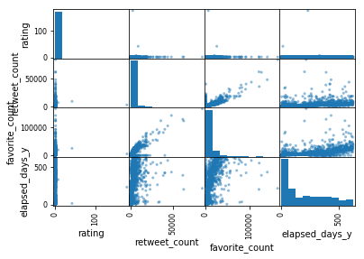

```python
import matplotlib.pyplot as plt
from pandas.plotting import scatter_matrix

#Ref https://www.youtube.com/watch?v=LoiVuDKxXBs
# create scatter matrix using rating,retweet_count, and favorite_count
print(scatter_matrix(twitter_archive_master[['rating','retweet_count','favorite_count','elapsed_days_y']]))
```

[output not shown]

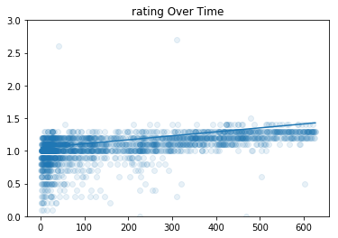

```python
# Ref https://stackoverflow.com/questions/19068862/how-to-overplot-a-line-on-a-scatter-plot-in-python
from numpy.polynomial.polynomial import polyfit

# Fit with polyfit
b, m = polyfit(twitter_archive_master['elapsed_days_y'],twitter_archive_master['rating'], 1)
x = twitter_archive_master['elapsed_days_y']
#scatter plot for retweet_counts over time
plt.scatter(twitter_archive_master['elapsed_days_y'],twitter_archive_master['rating'],alpha = .1)
plt.plot(x, b + m * x, '-')
plt.title('rating Over Time')
plt.ylim(0,3)
plt.show
```

```
<function matplotlib.pyplot.show(*args, **kw)>
```

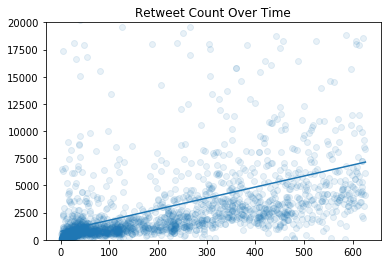

```python
# Fit with polyfit
b, m = polyfit(twitter_archive_master['elapsed_days_y'],twitter_archive_master['retweet_count'], 1)
x = twitter_archive_master['elapsed_days_y']
#scatter plot for retweet_counts over time
plt.scatter(twitter_archive_master['elapsed_days_y'],twitter_archive_master['retweet_count'],alpha = .1)
plt.plot(x, b + m * x, '-')
plt.title('Retweet Count Over Time')
plt.ylim(0,20000)
plt.show
```

```
<function matplotlib.pyplot.show(*args, **kw)>
```

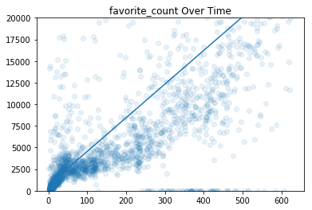

```python
# Fit with polyfit
b, m = polyfit(twitter_archive_master['elapsed_days_y'],twitter_archive_master['favorite_count'], 1)
x = twitter_archive_master['elapsed_days_y']
#scatter plot for favorite_count over time
plt.scatter(twitter_archive_master['elapsed_days_y'],twitter_archive_master['favorite_count'],alpha = .1)
plt.plot(x, b + m * x, '-')
plt.title('favorite_count Over Time')
plt.ylim(0,20000)
plt.show
```

```
<function matplotlib.pyplot.show(*args, **kw)>
```

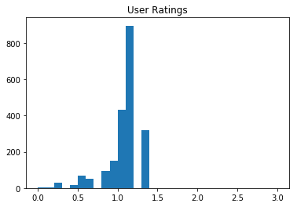

```python
import numpy as np

plt.hist(twitter_archive_master['rating'], range = (0,3), bins = 30)
plt.title('User Ratings')
plt.show
```

```python
# Ref https://machinelearningmastery.com/how-to-calculate-the-5-number-summary-for-your-data-in-python/

# calculate a 5-number summary for `rating`
from numpy import percentile
from numpy.random import rand
# generate data sample
data = twitter_archive_master['rating']
# calculate quartiles
quartiles = percentile(data, [25, 50, 75])
# calculate min/max
data_min, data_max = data.min(), data.max()
# print 5-number summary
print('Min: %.3f' % data_min)
print('Q1: %.3f' % quartiles[0])
print('Median: %.3f' % quartiles[1])
print('Q3: %.3f' % quartiles[2])
print('Max: %.3f' % data_max)
```

```
Min: 0.000
Q1: 1.000
Median: 1.100
Q3: 1.200
Max: 177.600
```

```python
# Ref https://machinelearningmastery.com/how-to-calculate-the-5-number-summary-for-your-data-in-python/

# calculate a 5-number summary for `retweet_count`
from numpy import percentile
from numpy.random import rand
# generate data sample
data = twitter_archive_master['retweet_count']
# calculate quartiles
quartiles = percentile(data, [25, 50, 75])
# calculate min/max
data_min, data_max = data.min(), data.max()
# print 5-number summary
print('Min: %.3f' % data_min)
print('Q1: %.3f' % quartiles[0])
print('Median: %.3f' % quartiles[1])
print('Q3: %.3f' % quartiles[2])
print('Max: %.3f' % data_max)
```

```
Min: 12.000
Q1: 600.500
Median: 1328.500
Q3: 3258.250
Max: 84121.000
```

```python
# Ref https://machinelearningmastery.com/how-to-calculate-the-5-number-summary-for-your-data-in-python/

# calculate a 5-number summary for `favorite_count`
from numpy import percentile
from numpy.random import rand
# generate data sample
data = twitter_archive_master['favorite_count']
# calculate quartiles
quartiles = percentile(data, [25, 50, 75])
# calculate min/max
data_min, data_max = data.min(), data.max()
# print 5-number summary
print('Min: %.3f' % data_min)
print('Q1: %.3f' % quartiles[0])
print('Median: %.3f' % quartiles[1])
print('Q3: %.3f' % quartiles[2])
print('Max: %.3f' % data_max)
```

```
Min: 0.000
Q1: 1610.000
Median: 3727.000
Q3: 10597.500
Max: 164928.000
```

#### Insight

- Retweet count and favortie count are positivly correlated with eachother
- Rating is not correlated to either retweet count or favorite count
- Retweet count and favorite count data distributions are both skewed right
- Rading data distribution is mostly around 1.1 to 1.2. There are a few outliers as high as 177.
- As time goes on user ratings, favorite count, and retweet count all trend upwards.

###### References

All references are done in code where they are used